# Python Test -- Jessica Wang

```python
import numpy as np
import pandas as pd
```

## 1. Write a Pandas program to create and display a DataFrame from a specified dictionary data which has the index labels.

```python
exam_data = {'name': ['Anastasia', 'Dima', 'Katherine', 'James', 'Emily', 'Michael', 'Matthew', 'Laura', 'Kevin', 'Jonas'],
'score': [12.5, 9, 16.5, np.nan, 9, 20, 14.5, np.nan, 8, 19],
'attempts': [1, 3, 2, 3, 2, 3, 1, 1, 2, 1],
'qualify': ['yes', 'no', 'yes', 'no', 'no', 'yes', 'yes', 'no', 'no', 'yes']}
labels = ['a', 'b', 'c', 'd', 'e', 'f', 'g', 'h', 'i', 'j']
df=pd.DataFrame(exam_data, index=labels)
df
```

|  | attempts | name | qualify | score |
| --- | --- | --- | --- | --- |
| a | 1 | Anastasia | yes | 12.5 |
| b | 3 | Dima | no | 9.0 |
| c | 2 | Katherine | yes | 16.5 |
| d | 3 | James | no | NaN |
| e | 2 | Emily | no | 9.0 |
| f | 3 | Michael | yes | 20.0 |
| g | 1 | Matthew | yes | 14.5 |
| h | 1 | Laura | no | NaN |
| i | 2 | Kevin | no | 8.0 |
| j | 1 | Jonas | yes | 19.0 |

## 2. Write a Pandas program to display a summary of the basic information about a specified DataFrame and its data.

```python
print("Summary of the basic information about this DataFrame and its data:")
print(df.info())
```

```
Summary of the basic information about this DataFrame and its data:
<class 'pandas.core.frame.DataFrame'>
Index: 10 entries, a to j
Data columns (total 4 columns):
attempts    10 non-null int64
name        10 non-null object
qualify     10 non-null object
score       8 non-null float64
dtypes: float64(1), int64(1), object(2)
memory usage: 400.0+ bytes
None
```

## 3. Write a Pandas program to select the specified columns and rows from a given data frame.

```python
df_3_0=df.iloc[np.r_[1,3,5,6],:]
df_3=df_3_0.loc[:,["name","score"]]
print("Select specific columns and rows:")
print(df_3)
```

```
Select specific columns and rows:
      name  score
b     Dima    9.0
d    James    NaN
f  Michael   20.0
g  Matthew   14.5
```

## 4. Write a Pandas program to select the rows where the score is missing, i.e. is NaN.

```python
df_4=df[df["score"].apply(np.isnan)]
print("Rows where score is missing:")
print(df_4)
```

```
Rows where score is missing:
   attempts   name qualify  score
d         3  James      no    NaN
h         1  Laura      no    NaN
```

## 5. Write a Pandas program to select the rows the score is between 15 and 20 (inclusive).

```python
df_5=df[(df["score"]>=15) & (df["score"]<=20)]

print("Rows where score between 15 and 20 (inclusive):")
print(df_5)
```

```
Rows where score between 15 and 20 (inclusive):
   attempts       name qualify  score
c         2  Katherine     yes   16.5
f         3    Michael     yes   20.0
j         1      Jonas     yes   19.0
```

## 6. Write a Pandas program to calculate the sum of the examination attempts by the students.

```python
df_6=df["attempts"].sum()
print("Sum of the examination attempts by the students: " + str(df_6))
```

```
Sum of the examination attempts by the students: 19
```

## 7. Write a Pandas program to sort the DataFrame first by 'name' in descending order, then by 'score' in ascending order.

```python
df_7=df.sort_values(by=["name","score"], ascending=[False, True])

print("Sort the data frame first by 'name' in descending order, then by 'score' in ascending order: ")
print(df_7)
```

```
Sort the data frame first by 'name' in descending order, then by 'score' in ascending order:
   attempts       name qualify  score
f         3    Michael     yes   20.0
g         1    Matthew     yes   14.5
h         1      Laura      no    NaN
i         2      Kevin      no    8.0
c         2  Katherine     yes   16.5
j         1      Jonas     yes   19.0
d         3      James      no    NaN
e         2      Emily      no    9.0
b         3       Dima      no    9.0
a         1  Anastasia     yes   12.5
```

## 8. Write a Pandas program to get list from DataFrame column headers.

```python
list(df.columns)
```

```
['attempts', 'name', 'qualify', 'score']
```

## 9. Write a Pandas program to rename columns of a given DataFrame

```python
df_9=pd.DataFrame({'col1': [1,2,3],
'col2': [4,5,6],
'col3': [7,8,9]})
df_9
```

|  | col1 | col2 | col3 |
| --- | --- | --- | --- |
| 0 | 1 | 4 | 7 |
| 1 | 2 | 5 | 8 |
| 2 | 3 | 6 | 9 |

```python
df_9_1=df_9.rename(columns={'col1':'Column1','col2': 'Column2','col3':'Column3'})

print("New DataFrame after renaming columns:")
print(df_9_1)
```

```
New DataFrame after renaming columns:
   Column1  Column2  Column3
0        1        4        7
1        2        5        8
2        3        6        9
```

## 10. Write a Pandas program to select rows from a given DataFrame based on values in some columns.

```python
df_10=pd.DataFrame({'col1': [1,4,3,4,5],
'col2': [4,5,6,7,8],
'col3': [7,8,9,0,1]})
df_10
```

|  | col1 | col2 | col3 |
| --- | --- | --- | --- |
| 0 | 1 | 4 | 7 |
| 1 | 4 | 5 | 8 |
| 2 | 3 | 6 | 9 |
| 3 | 4 | 7 | 0 |
| 4 | 5 | 8 | 1 |

```python
df_10_1=df_10[df_10["col1"]==4]

print("Rows for colum1 value == 4")
print(df_10_1)
```

```
Rows for colum1 value == 4
   col1  col2  col3
1     4     5     8
3     4     7     0
```

## 11. Write a Pandas program to widen output display to see more columns.

```python
pd.set_option('display.max_columns', None)
```

## 12. Write a Pandas program to replace all the NaN values with Zero's in a column of a dataframe.

```python
df_12=df.copy()
df_12["score"].fillna(0,inplace=True)

print("New DataFrame replacing all NaN with 0:")
print(df_12)
```

```
New DataFrame replacing all NaN with 0:
   attempts       name qualify  score
a         1  Anastasia     yes   12.5
b         3       Dima      no    9.0
c         2  Katherine     yes   16.5
d         3      James      no    0.0
e         2      Emily      no    9.0
f         3    Michael     yes   20.0
g         1    Matthew     yes   14.5
h         1      Laura      no    0.0
i         2      Kevin      no    8.0
j         1      Jonas     yes   19.0
```

## 13. Write a Pandas program to reset index in a given DataFrame.

```python
df_13=df.copy()
df_13=df.reset_index(drop=True)
df_13_1=df_13.iloc[2:,:].reset_index()

print("Original DataFrame")
print(df_13)
print("After removing first and second rows")
print(df_13.iloc[2:,:])
print("Reset the Index:")
print(df_13_1)
```

```
Original DataFrame
   attempts       name qualify  score
0         1  Anastasia     yes   12.5
1         3       Dima      no    9.0
2         2  Katherine     yes   16.5
3         3      James      no    NaN
4         2      Emily      no    9.0
5         3    Michael     yes   20.0
6         1    Matthew     yes   14.5
7         1      Laura      no    NaN
8         2      Kevin      no    8.0
9         1      Jonas     yes   19.0
After removing first and second rows
   attempts       name qualify  score
2         2  Katherine     yes   16.5
```

[output cut: 17 more lines]

## 14. Write a Pandas program to devide a DataFrame in a given ratio.

```python
df_14=pd.DataFrame({'0': [0.316147,	-0.81341,	0.869615,	-0.892915,	-0.341126,	1.857342,	-0.044353,	-0.726346,	-1.350726,	1.051666],
'1': [-0.767359,	-2.522672,	1.194704,	-0.055133,	0.518266,	1.361229,	-1.205002,	-0.535147,	0.563117,	-0.441533]})
df_14
```

|  | 0 | 1 |
| --- | --- | --- |
| 0 | 0.316147 | -0.767359 |
| 1 | -0.813410 | -2.522672 |
| 2 | 0.869615 | 1.194704 |
| 3 | -0.892915 | -0.055133 |
| 4 | -0.341126 | 0.518266 |
| 5 | 1.857342 | 1.361229 |
| 6 | -0.044353 | -1.205002 |
| 7 | -0.726346 | -0.535147 |
| 8 | -1.350726 | 0.563117 |
| 9 | 1.051666 | -0.441533 |

```python
df_14_70=df_14.sample(frac=0.7)
df_14_30=df_14.drop(df_14_70.index)
print("70% of the said DataFrame:")
print(df_14_70)
print("30% of the said DataFrame:")
print(df_14_30)
```

```
70% of the said DataFrame:
          0         1
8 -1.350726  0.563117
5  1.857342  1.361229
3 -0.892915 -0.055133
2  0.869615  1.194704
4 -0.341126  0.518266
0  0.316147 -0.767359
6 -0.044353 -1.205002
30% of the said DataFrame:
          0         1
1 -0.813410 -2.522672
7 -0.726346 -0.535147
9  1.051666 -0.441533
```

## 15. Write a Pandas program to convert DataFrame column type from string to datetime.

```python
df_15=pd.DataFrame( {"String Date":['3/11/2000','3/12/2000','3/13/2000']})
print("Original String DataFrame:")
print(df_15)
df_15["String Date"]=pd.to_datetime(df_15["String Date"],format="%m/%d/%Y")
print("String to Datetime DataFrame:")
print(df_15)
```

```
Original String DataFrame:
  String Date
0   3/11/2000
1   3/12/2000
2   3/13/2000
String to Datetime DataFrame:
  String Date
0  2000-03-11
1  2000-03-12
2  2000-03-13
```

## 16. Write a Pandas program to create a DataFrame from a Numpy array and specify the index column and column headers.

```python
col_i=["Column"+str(i) for i in range(1,4)]
row_i=["Index"+str(i) for i in range(1,16)]
col_type=["int32","float32","float32"]

arr_16=np.zeros(15,dtype=list(zip(col_i,col_type)))
df_16=pd.DataFrame(arr_16,index=row_i)
print(df_16)
```

```
         Column1  Column2  Column3
Index1         0      0.0      0.0
Index2         0      0.0      0.0
Index3         0      0.0      0.0
Index4         0      0.0      0.0
Index5         0      0.0      0.0
Index6         0      0.0      0.0
Index7         0      0.0      0.0
Index8         0      0.0      0.0
Index9         0      0.0      0.0
Index10        0      0.0      0.0
Index11        0      0.0      0.0
Index12        0      0.0      0.0
Index13        0      0.0      0.0
Index14        0      0.0      0.0
Index15        0      0.0      0.0
```

## 17. Write a Pandas program to find the row for where the value of a given column is maximum.

```python
df_17=pd.DataFrame({'col1': [1,2,3,4,7],
'col2': [4,5,6,9,5],
'col3': [7,8,12,1,11]})
df_17
```

|  | col1 | col2 | col3 |
| --- | --- | --- | --- |
| 0 | 1 | 4 | 7 |
| 1 | 2 | 5 | 8 |
| 2 | 3 | 6 | 12 |
| 3 | 4 | 9 | 1 |
| 4 | 7 | 5 | 11 |

```python
print("Row where col1 has maximum value:")
print(df_17.idxmax()[0])
print("Row where col2 has maximum value:")
print(df_17.idxmax()[1])
print("Row where col3 has maximum value:")
print(df_17.idxmax()[2])
```

```
Row where col1 has maximum value:
4
Row where col2 has maximum value:
3
Row where col3 has maximum value:
2
```

## 18. Write a Pandas program to convert the datatype of a given column (floats to ints).

```python
df_18=df_12.copy()
df_18["score"]=df_18["score"].astype("int64")

print("Data types of the columns of the said DataFrame:")
print(df_12.dtypes)
print("Now change the Data type of 'score' column from float to int:")
print(df_18)
print("Data types of the columns of the DataFrame now:")
print(df_18.dtypes)
```

```
Data types of the columns of the said DataFrame:
attempts      int64
name         object
qualify      object
score       float64
dtype: object
Now change the Data type of 'score' column from float to int:
   attempts       name qualify  score
a         1  Anastasia     yes     12
b         3       Dima      no      9
c         2  Katherine     yes     16
d         3      James      no      0
e         2      Emily      no      9
f         3    Michael     yes     20
g         1    Matthew     yes     14
h         1      Laura      no      0
i         2      Kevin      no      8
j         1      Jonas     yes     19
Data types of the columns of the DataFrame now:
attempts     int64
name        object
qualify     object
score        int64
dtype: object
```

## 19. Write a Pandas program to convert a given list of lists into a Dataframe.

```python
list_19=[[2, 4], [1, 3]]
df_19=pd.DataFrame(list_19,columns=["col1","col2"])
print("New DataFrame")
print(df_19)
```

```
New DataFrame
   col1  col2
0     2     4
1     1     3
```

## 20. Write a Pandas program to group by the first column and get second column as lists in rows.

```python
df_20=pd.DataFrame({'col1': ['C1',	'C1',	'C2',	'C2',	'C2',	'C3',	'C2'],
'col2': [1,	2,	3,	3,	4,	6,	5]})
df_20_1=df_20.groupby("col1")["col2"].apply(list)

print("Original DataFrame")
print(df_20)
print("Group on the col1")
print(df_20_1)
```

```
Original DataFrame
  col1  col2
0   C1     1
1   C1     2
2   C2     3
3   C2     3
4   C2     4
5   C3     6
6   C2     5
Group on the col1
col1
C1          [1, 2]
C2    [3, 3, 4, 5]
C3             [6]
Name: col2, dtype: object
```

```python
df_20_1
```

```
col1
C1          [1, 2]
C2    [3, 3, 4, 5]
C3             [6]
Name: col2, dtype: object
```

## Scikit learn

```python
import numpy as np
import pandas as pd

from sklearn.linear_model import LogisticRegression as LR
from sklearn.model_selection import train_test_split
from sklearn.preprocessing import OneHotEncoder,MinMaxScaler
from sklearn.metrics import confusion_matrix, auc, roc_curve, accuracy_score, precision_score,recall_score

#from imblearn.over_sampling import SMOTE
import matplotlib.pyplot as plt
import seaborn as sns
import statsmodels.api as sm
```

```python
import sklearn
sklearn.__version__
```

```
'1.1.0'
```

```python
pd.set_option('display.max_columns', None)
```

### 1. Please create a Logistic Regression model against the dataset < UCI_Credit_Card.csv> using all possible independent variable, dependent variable is: default.payment.next.month. (Please split into Training-80% and Test – 20% Randomly and test your training model onto test data).

```python
# Import data
UCI_data=pd.read_csv("UCI_Credit_Card.csv",delimiter=";")
UCI_data.drop(columns=["ID"],axis=1,inplace=True)
UCI_data.head()
```

|  | LIMIT_BAL | SEX | EDUCATION | MARRIAGE | AGE | PAY_0 | PAY_2 | PAY_3 | PAY_4 | PAY_5 | PAY_6 | BILL_AMT1 | BILL_AMT2 | BILL_AMT3 | BILL_AMT4 | BILL_AMT5 | BILL_AMT6 | PAY_AMT1 | PAY_AMT2 | PAY_AMT3 | PAY_AMT4 | PAY_AMT5 | PAY_AMT6 | default.payment.next.month |
| --- | --- | --- | --- | --- | --- | --- | --- | --- | --- | --- | --- | --- | --- | --- | --- | --- | --- | --- | --- | --- | --- | --- | --- | --- |
| 0 | 20000.0 | 2 | 2 | 1 | 24 | 2 | 2 | -1 | -1 | -2 | -2 | 3913.0 | 3102.0 | 689.0 | 0.0 | 0.0 | 0.0 | 0.0 | 689.0 | 0.0 | 0.0 | 0.0 | 0.0 | 1 |
| 1 | 120000.0 | 2 | 2 | 2 | 26 | -1 | 2 | 0 | 0 | 0 | 2 | 2682.0 | 1725.0 | 2682.0 | 3272.0 | 3455.0 | 3261.0 | 0.0 | 1000.0 | 1000.0 | 1000.0 | 0.0 | 2000.0 | 1 |
| 2 | 90000.0 | 2 | 2 | 2 | 34 | 0 | 0 | 0 | 0 | 0 | 0 | 29239.0 | 14027.0 | 13559.0 | 14331.0 | 14948.0 | 15549.0 | 1518.0 | 1500.0 | 1000.0 | 1000.0 | 1000.0 | 5000.0 | 0 |
| 3 | 50000.0 | 2 | 2 | 1 | 37 | 0 | 0 | 0 | 0 | 0 | 0 | 46990.0 | 48233.0 | 49291.0 | 28314.0 | 28959.0 | 29547.0 | 2000.0 | 2019.0 | 1200.0 | 1100.0 | 1069.0 | 1000.0 | 0 |
| 4 | 50000.0 | 1 | 2 | 1 | 57 | -1 | 0 | -1 | 0 | 0 | 0 | 8617.0 | 5670.0 | 35835.0 | 20940.0 | 19146.0 | 19131.0 | 2000.0 | 36681.0 | 10000.0 | 9000.0 | 689.0 | 679.0 | 0 |

```python
# variables exporing
UCI_data.describe().T
```

|  | count | mean | std | min | 25% | 50% | 75% | max |
| --- | --- | --- | --- | --- | --- | --- | --- | --- |
| LIMIT_BAL | 30000.0 | 167484.322667 | 129747.661567 | 10000.0 | 50000.00 | 140000.0 | 240000.00 | 1000000.0 |
| SEX | 30000.0 | 1.603733 | 0.489129 | 1.0 | 1.00 | 2.0 | 2.00 | 2.0 |
| EDUCATION | 30000.0 | 1.853133 | 0.790349 | 0.0 | 1.00 | 2.0 | 2.00 | 6.0 |
| MARRIAGE | 30000.0 | 1.551867 | 0.521970 | 0.0 | 1.00 | 2.0 | 2.00 | 3.0 |
| AGE | 30000.0 | 35.485500 | 9.217904 | 21.0 | 28.00 | 34.0 | 41.00 | 79.0 |
| PAY_0 | 30000.0 | -0.016700 | 1.123802 | -2.0 | -1.00 | 0.0 | 0.00 | 8.0 |
| PAY_2 | 30000.0 | -0.133767 | 1.197186 | -2.0 | -1.00 | 0.0 | 0.00 | 8.0 |
| PAY_3 | 30000.0 | -0.166200 | 1.196868 | -2.0 | -1.00 | 0.0 | 0.00 | 8.0 |
| PAY_4 | 30000.0 | -0.220667 | 1.169139 | -2.0 | -1.00 | 0.0 | 0.00 | 8.0 |
| PAY_5 | 30000.0 | -0.266200 | 1.133187 | -2.0 | -1.00 | 0.0 | 0.00 | 8.0 |
| PAY_6 | 30000.0 | -0.291100 | 1.149988 | -2.0 | -1.00 | 0.0 | 0.00 | 8.0 |
| BILL_AMT1 | 30000.0 | 51223.330900 | 73635.860576 | -165580.0 | 3558.75 | 22381.5 | 67091.00 | 964511.0 |
| BILL_AMT2 | 30000.0 | 49179.075167 | 71173.768783 | -69777.0 | 2984.75 | 21200.0 | 64006.25 | 983931.0 |
| BILL_AMT3 | 30000.0 | 47013.154800 | 69349.387427 | -157264.0 | 2666.25 | 20088.5 | 60164.75 | 1664089.0 |
| BILL_AMT4 | 30000.0 | 43262.948967 | 64332.856134 | -170000.0 | 2326.75 | 19052.0 | 54506.00 | 891586.0 |
| BILL_AMT5 | 30000.0 | 40311.400967 | 60797.155770 | -81334.0 | 1763.00 | 18104.5 | 50190.50 | 927171.0 |
| BILL_AMT6 | 30000.0 | 38871.760400 | 59554.107537 | -339603.0 | 1256.00 | 17071.0 | 49198.25 | 961664.0 |
| PAY_AMT1 | 30000.0 | 5663.580500 | 16563.280354 | 0.0 | 1000.00 | 2100.0 | 5006.00 | 873552.0 |
| PAY_AMT2 | 30000.0 | 5921.163500 | 23040.870402 | 0.0 | 833.00 | 2009.0 | 5000.00 | 1684259.0 |
| PAY_AMT3 | 30000.0 | 5225.681500 | 17606.961470 | 0.0 | 390.00 | 1800.0 | 4505.00 | 896040.0 |
| PAY_AMT4 | 30000.0 | 4826.076867 | 15666.159744 | 0.0 | 296.00 | 1500.0 | 4013.25 | 621000.0 |
| PAY_AMT5 | 30000.0 | 4799.387633 | 15278.305679 | 0.0 | 252.50 | 1500.0 | 4031.50 | 426529.0 |
| PAY_AMT6 | 30000.0 | 5215.502567 | 17777.465775 | 0.0 | 117.75 | 1500.0 | 4000.00 | 528666.0 |
| default.payment.next.month | 30000.0 | 0.221200 | 0.415062 | 0.0 | 0.00 | 0.0 | 0.00 | 1.0 |

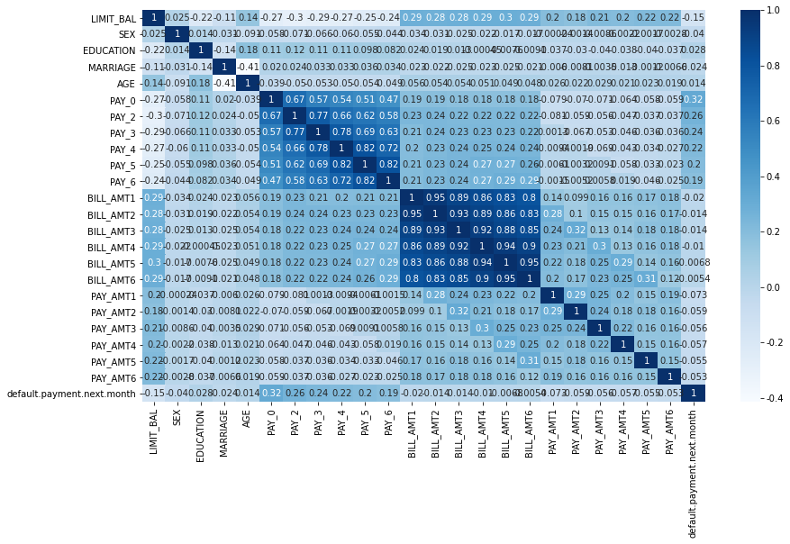

```python
#UCI_data.corr()
plt.figure(figsize=(14,8))
sns.heatmap(UCI_data.corr(), cmap='Blues', annot=True)
plt.show()
```

```python
print("Dependent unique: " + str(UCI_data["default.payment.next.month"].unique()))
print("SEX unique: " + str(UCI_data["SEX"].unique()))
print("EDUCATION unique: " + str(UCI_data["EDUCATION"].unique()))
print("MARRIAGE unique: " + str(UCI_data["MARRIAGE"].unique()))
```

```
Dependent unique: [1 0]
SEX unique: [2 1]
EDUCATION unique: [2 1 3 5 4 6 0]
MARRIAGE unique: [1 2 3 0]
```

```python
# Keep EDUCATION LABLE VALUE
# One-hot Encoding for SEX and MARRIAGE
OH_SEX=OneHotEncoder(categories='auto').fit_transform(UCI_data.iloc[:,1:2]).toarray()
OH_MARRIAGE=OneHotEncoder(categories='auto').fit_transform(UCI_data.iloc[:,3:4]).toarray()

OH_SEX_1=pd.DataFrame(OH_SEX,columns=["SEX_1","SEX_2"])
OH_MARRIAGE_1=pd.DataFrame(OH_MARRIAGE,columns=["MARRIAGE_1","MARRIAGE_2","MARRIAGE_3","MARRIAGE_4"])

OH_DATA=pd.concat([OH_SEX_1,OH_MARRIAGE_1],axis=1)
OH_DATA.head()
```

|  | SEX_1 | SEX_2 | MARRIAGE_1 | MARRIAGE_2 | MARRIAGE_3 | MARRIAGE_4 |
| --- | --- | --- | --- | --- | --- | --- |
| 0 | 0.0 | 1.0 | 0.0 | 1.0 | 0.0 | 0.0 |
| 1 | 0.0 | 1.0 | 0.0 | 0.0 | 1.0 | 0.0 |
| 2 | 0.0 | 1.0 | 0.0 | 0.0 | 1.0 | 0.0 |
| 3 | 0.0 | 1.0 | 0.0 | 1.0 | 0.0 | 0.0 |
| 4 | 1.0 | 0.0 | 0.0 | 1.0 | 0.0 | 0.0 |

```python
# Check PAY_0-PAY_6
UCI_data["PAY_0"].value_counts()
UCI_data["PAY_2"].value_counts()
```

```
 0    15730
-1     6050
 2     3927
-2     3782
 3      326
 4       99
 1       28
 5       25
 7       20
 6       12
 8        1
Name: PAY_2, dtype: int64
```

```python
## Scaler numeric data to 0 - 1
from sklearn.preprocessing import MinMaxScaler
NUM_DATA=UCI_data.iloc[:,np.r_[0,2,5:23]]
scaler = MinMaxScaler()
result = scaler.fit_transform(NUM_DATA)
NUM_DATA_NEW=pd.DataFrame(result,columns=NUM_DATA.columns)
NUM_DATA_NEW.head()
```

|  | LIMIT_BAL | EDUCATION | PAY_0 | PAY_2 | PAY_3 | PAY_4 | PAY_5 | PAY_6 | BILL_AMT1 | BILL_AMT2 | BILL_AMT3 | BILL_AMT4 | BILL_AMT5 | BILL_AMT6 | PAY_AMT1 | PAY_AMT2 | PAY_AMT3 | PAY_AMT4 | PAY_AMT5 | PAY_AMT6 |
| --- | --- | --- | --- | --- | --- | --- | --- | --- | --- | --- | --- | --- | --- | --- | --- | --- | --- | --- | --- | --- |
| 0 | 0.010101 | 0.333333 | 0.4 | 0.4 | 0.1 | 0.1 | 0.0 | 0.0 | 0.149982 | 0.069164 | 0.086723 | 0.160138 | 0.080648 | 0.260979 | 0.000000 | 0.000409 | 0.000000 | 0.000000 | 0.000000 | 0.000000 |
| 1 | 0.111111 | 0.333333 | 0.1 | 0.4 | 0.2 | 0.2 | 0.2 | 0.4 | 0.148892 | 0.067858 | 0.087817 | 0.163220 | 0.084074 | 0.263485 | 0.000000 | 0.000594 | 0.001116 | 0.001610 | 0.000000 | 0.003783 |
| 2 | 0.080808 | 0.333333 | 0.2 | 0.2 | 0.2 | 0.2 | 0.2 | 0.2 | 0.172392 | 0.079532 | 0.093789 | 0.173637 | 0.095470 | 0.272928 | 0.001738 | 0.000891 | 0.001116 | 0.001610 | 0.002345 | 0.009458 |
| 3 | 0.040404 | 0.333333 | 0.2 | 0.2 | 0.2 | 0.2 | 0.2 | 0.2 | 0.188100 | 0.111995 | 0.113407 | 0.186809 | 0.109363 | 0.283685 | 0.002290 | 0.001199 | 0.001339 | 0.001771 | 0.002506 | 0.001892 |
| 4 | 0.040404 | 0.333333 | 0.1 | 0.2 | 0.1 | 0.2 | 0.2 | 0.2 | 0.154144 | 0.071601 | 0.106020 | 0.179863 | 0.099633 | 0.275681 | 0.002290 | 0.021779 | 0.011160 | 0.014493 | 0.001615 | 0.001284 |

```python
UCI_data_new=pd.concat([OH_DATA,NUM_DATA_NEW],axis=1)
UCI_data_new.head()
```

|  | SEX_1 | SEX_2 | MARRIAGE_1 | MARRIAGE_2 | MARRIAGE_3 | MARRIAGE_4 | LIMIT_BAL | EDUCATION | PAY_0 | PAY_2 | PAY_3 | PAY_4 | PAY_5 | PAY_6 | BILL_AMT1 | BILL_AMT2 | BILL_AMT3 | BILL_AMT4 | BILL_AMT5 | BILL_AMT6 | PAY_AMT1 | PAY_AMT2 | PAY_AMT3 | PAY_AMT4 | PAY_AMT5 | PAY_AMT6 |
| --- | --- | --- | --- | --- | --- | --- | --- | --- | --- | --- | --- | --- | --- | --- | --- | --- | --- | --- | --- | --- | --- | --- | --- | --- | --- | --- |
| 0 | 0.0 | 1.0 | 0.0 | 1.0 | 0.0 | 0.0 | 0.010101 | 0.333333 | 0.4 | 0.4 | 0.1 | 0.1 | 0.0 | 0.0 | 0.149982 | 0.069164 | 0.086723 | 0.160138 | 0.080648 | 0.260979 | 0.000000 | 0.000409 | 0.000000 | 0.000000 | 0.000000 | 0.000000 |
| 1 | 0.0 | 1.0 | 0.0 | 0.0 | 1.0 | 0.0 | 0.111111 | 0.333333 | 0.1 | 0.4 | 0.2 | 0.2 | 0.2 | 0.4 | 0.148892 | 0.067858 | 0.087817 | 0.163220 | 0.084074 | 0.263485 | 0.000000 | 0.000594 | 0.001116 | 0.001610 | 0.000000 | 0.003783 |
| 2 | 0.0 | 1.0 | 0.0 | 0.0 | 1.0 | 0.0 | 0.080808 | 0.333333 | 0.2 | 0.2 | 0.2 | 0.2 | 0.2 | 0.2 | 0.172392 | 0.079532 | 0.093789 | 0.173637 | 0.095470 | 0.272928 | 0.001738 | 0.000891 | 0.001116 | 0.001610 | 0.002345 | 0.009458 |
| 3 | 0.0 | 1.0 | 0.0 | 1.0 | 0.0 | 0.0 | 0.040404 | 0.333333 | 0.2 | 0.2 | 0.2 | 0.2 | 0.2 | 0.2 | 0.188100 | 0.111995 | 0.113407 | 0.186809 | 0.109363 | 0.283685 | 0.002290 | 0.001199 | 0.001339 | 0.001771 | 0.002506 | 0.001892 |
| 4 | 1.0 | 0.0 | 0.0 | 1.0 | 0.0 | 0.0 | 0.040404 | 0.333333 | 0.1 | 0.2 | 0.1 | 0.2 | 0.2 | 0.2 | 0.154144 | 0.071601 | 0.106020 | 0.179863 | 0.099633 | 0.275681 | 0.002290 | 0.021779 | 0.011160 | 0.014493 | 0.001615 | 0.001284 |

```python
# Split into Training and Testing data
X = UCI_data_new
y = UCI_data.iloc[:,-1]
X_train, X_test, Y_train, Y_test = train_test_split(X,y,test_size=0.2,random_state=500)
```

```python
# Logistic Regression model with different parameters
#lr = LR(penalty="l2",solver="liblinear",max_iter=1001,C=1e9).fit(X_train,Y_train)
lr = LR(C=1e9, fit_intercept=False,max_iter=1002).fit(X_train,Y_train)
print("LR model: "+ str(lr.score(X_test,Y_test)))
'''
lr1 = LR(penalty="l1",solver="liblinear",max_iter=1001).fit(X_train,Y_train)
lr2 = LR(penalty="l1",solver="saga",max_iter=1001).fit(X_train,Y_train)
lr3 = LR(penalty="l2",solver="liblinear",max_iter=1001).fit(X_train,Y_train)
lr4 = LR(penalty="l2",solver="saga",max_iter=1001).fit(X_train,Y_train)
print("LR model 1: "+ str(lr1.score(X_test,Y_test)))
print("LR model 2: "+ str(lr2.score(X_test,Y_test)))
print("LR model 3: "+ str(lr3.score(X_test,Y_test)))
print("LR model 4: "+ str(lr4.score(X_test,Y_test)))
'''
```

```
LR model: 0.8105
```

[output not shown]

```python
print(lr.intercept_)
print(lr.coef_)
```

```
[0.]
[[ -1.53074724  -1.66654646  -1.48859009  -0.4535051   -0.68137337
   -0.57382514  -0.60510981  -0.53849775   5.84086265   0.87725283
    0.65172185   0.34071026   0.17732904   0.26458281  -7.04468185
    3.25484724   2.07972194  -0.1351929    0.27372376   1.24207218
  -13.12379302 -16.20558731  -2.0797894   -2.66047181  -1.93217644
   -1.42733686]]
```

### 2. Visualize the Prediction vs Actual, and also the basic Test output including, but not limit to T-Test, P-value etc.

```python
# confusion matrics
Y_pred=lr.predict(X_test)
cnf_matrix=confusion_matrix(Y_test,Y_pred)
cnf_matrix
```

```
array([[4552,  146],
       [ 991,  311]])
```

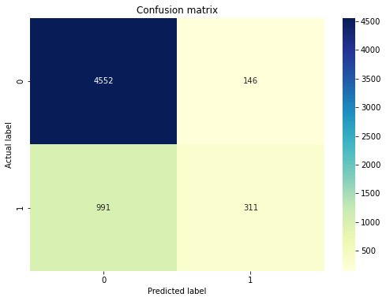

```python
# create heatmap
plt.figure(figsize=(7,5))
class_names=[0,1]
tick_marks = np.arange(len(class_names))
plt.xticks(tick_marks, class_names)
plt.yticks(tick_marks, class_names)
sns.heatmap(pd.DataFrame(cnf_matrix), annot=True, cmap="YlGnBu" ,fmt='g')
plt.tight_layout()
plt.title('Confusion matrix')
plt.ylabel('Actual label')
plt.xlabel('Predicted label')
```

```python
# Other Model prediction evaluation
y_score_test = lr.predict_proba(X_test)[:, 1]
fpr, tpr, thresholds = roc_curve(Y_test, y_score_test)
roc_auc = auc(fpr, tpr)

print("Accuracy:",accuracy_score(Y_test,Y_pred))
print("Precision:",precision_score(Y_test,Y_pred))
print("Recall:",recall_score(Y_test,Y_pred))
print("ROC:",roc_auc)
```

```
Accuracy: 0.8105
Precision: 0.6805251641137856
Recall: 0.23886328725038403
ROC: 0.718236393693692
```

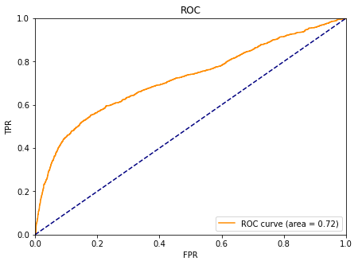

```python
# Plot ROC curve
plt.figure(figsize=(7,5))
plt.plot(fpr, tpr, color='darkorange', label='ROC curve (area = %0.2f)' % roc_auc)
plt.plot([0, 1], [0, 1], color='navy', linestyle='--')
plt.xlim([0.0, 1.0])
plt.ylim([0.0, 1.0])
plt.xlabel('FPR')
plt.ylabel('TPR')
plt.title('ROC')
plt.legend(loc="lower right")
```

```python
# Summary Output
X_train_c = sm.add_constant(X_train)
logit_model=sm.Logit(Y_train,X_train)
result=logit_model.fit()
print(result.summary2())
```

```
Optimization terminated successfully.
         Current function value: 0.464283
         Iterations 8
                              Results: Logit
===========================================================================
Model:              Logit                      Pseudo R-squared: 0.124
Dependent Variable: default.payment.next.month AIC:              22337.5852
Date:               2022-05-15 21:57           BIC:              22547.8163
No. Observations:   24000                      Log-Likelihood:   -11143.
Df Model:           25                         LL-Null:          -12714.
Df Residuals:       23974                      LLR p-value:      0.0000
Converged:          1.0000                     Scale:            1.0000
No. Iterations:     8.0000
---------------------------------------------------------------------------
              Coef.     Std.Err.     z    P>|z|      [0.025       0.975]
---------------------------------------------------------------------------
SEX_1         -1.5301 912138.0878 -0.0000 1.0000 -1787759.3311 1787756.2710
SEX_2         -1.6659 912138.0878 -0.0000 1.0000 -1787759.4669 1787756.1352
MARRIAGE_1    -1.4921 912138.0878 -0.0000 1.0000 -1787759.2932 1787756.3090
MARRIAGE_2    -0.4519 912138.0878 -0.0000 1.0000 -1787758.2529 1787757.3492
MARRIAGE_3    -0.6798 912138.0878 -0.0000 1.0000 -1787758.4808 1787757.1213
MARRIAGE_4    -0.5722 912138.0878 -0.0000 1.0000 -1787758.3733 1787757.2288
LIMIT_BAL     -0.6052      0.1717 -3.5247 0.0004       -0.9418      -0.2687
EDUCATION     -0.5387      0.1401 -3.8462 0.0001       -0.8133      -0.2642
PAY_0          5.8396      0.1979 29.5059 0.0000        5.4517       6.2275
PAY_2          0.8813      0.2250  3.9172 0.0001        0.4404       1.3223
PAY_3          0.6465      0.2535  2.5504 0.0108        0.1497       1.1433
PAY_4          0.3445      0.2792  1.2340 0.2172       -0.2027       0.8917
PAY_5          0.1748      0.3015  0.5800 0.5619       -0.4160       0.7657
PAY_6          0.2647      0.2476  1.0689 0.2851       -0.2206       0.7500
BILL_AMT1     -7.0551      1.4660 -4.8125 0.0000       -9.9284      -4.1818
BILL_AMT2      3.1998      1.7801  1.7975 0.0722       -0.2891       6.6888
BILL_AMT3      2.2605      2.6947  0.8389 0.4016       -3.0211       7.5421
BILL_AMT4     -0.1569      1.6173 -0.0970 0.9227       -3.3267       3.0129
BILL_AMT5      0.2759      1.7345  0.1591 0.8736       -3.1237       3.6754
BILL_AMT6      1.2070      1.7796  0.6783 0.4976       -2.2809       4.6949
PAY_AMT1     -12.9676      2.3299 -5.5657 0.0000      -17.5342      -8.4011
PAY_AMT2     -16.5435      3.9729 -4.1640 0.0000      -24.3303      -8.7567
PAY_AMT3      -2.0497      1.7064 -1.2011 0.2297       -5.3943       1.2949
PAY_AMT4      -2.6380      1.2649 -2.0855 0.0370       -5.1172      -0.1588
PAY_AMT5      -1.9382      0.8778 -2.2079 0.0273       -3.6587      -0.2177
PAY_AMT6      -1.4153      0.7775 -1.8204 0.0687       -2.9391       0.1085
===========================================================================
```

## Try to improve the model

```python
#chi2 test for category variables - "SEX","EDUCATION","MARRIAGE" and dependent y
from sklearn.feature_selection import chi2
X_chi2=UCI_data[["SEX","EDUCATION","MARRIAGE"]]
f_p_values=pd.DataFrame(chi2(X_chi2,y))
f_p_values.columns=X_chi2.columns
f_p_values.index=[["F-score","p-value"]]
f_p_values
#remove "MARRIAGE" since it is not significant at 0.05 level.
```

|  | SEX | EDUCATION | MARRIAGE |
| --- | --- | --- | --- |
| F-score | 7.146367 | 7.931259 | 3.120010 |
| p-value | 0.007512 | 0.004859 | 0.077336 |

```python
#BILL_AMT1 coeficent is significant in the model, while BILL_AMT2-6 are not.
#On the other hand, the correlation of them are quite high
#remove BILL_AMT2-6 from the model
```

```python
# Now build a new model with the above improvement
X_train_2=X_train.drop(columns=["MARRIAGE_1","MARRIAGE_2","MARRIAGE_3","MARRIAGE_4","BILL_AMT2","BILL_AMT3","BILL_AMT4","BILL_AMT5","BILL_AMT6"])
logit_model=sm.Logit(Y_train,X_train_2)
result=logit_model.fit()
print(result.summary2())
```

```
Optimization terminated successfully.
         Current function value: 0.465687
         Iterations 7
                              Results: Logit
===========================================================================
Model:              Logit                      Pseudo R-squared: 0.121
Dependent Variable: default.payment.next.month AIC:              22386.9829
Date:               2022-05-15 21:57           BIC:              22524.4416
No. Observations:   24000                      Log-Likelihood:   -11176.
Df Model:           16                         LL-Null:          -12714.
Df Residuals:       23983                      LLR p-value:      0.0000
Converged:          1.0000                     Scale:            1.0000
No. Iterations:     7.0000
------------------------------------------------------------------------------
              Coef.      Std.Err.       z        P>|z|      [0.025      0.975]
------------------------------------------------------------------------------
SEX_1         -2.2537      0.0828    -27.2116    0.0000     -2.4160    -2.0913
SEX_2         -2.3795      0.0815    -29.2038    0.0000     -2.5392    -2.2198
LIMIT_BAL     -0.4213      0.1679     -2.5095    0.0121     -0.7504    -0.0923
EDUCATION     -0.3796      0.1359     -2.7928    0.0052     -0.6459    -0.1132
PAY_0          5.9055      0.1979     29.8433    0.0000      5.5176     6.2933
PAY_2          0.8324      0.2245      3.7070    0.0002      0.3923     1.2725
PAY_3          0.7019      0.2524      2.7811    0.0054      0.2073     1.1966
PAY_4          0.3815      0.2782      1.3710    0.1704     -0.1639     0.9268
PAY_5          0.1987      0.2999      0.6624    0.5077     -0.3891     0.7865
PAY_6          0.3545      0.2441      1.4520    0.1465     -0.1240     0.8330
BILL_AMT1     -1.9771      0.3417     -5.7855    0.0000     -2.6469    -1.3073
PAY_AMT1     -10.1581      2.0863     -4.8690    0.0000    -14.2472    -6.0690
PAY_AMT2     -14.8774      3.5333     -4.2106    0.0000    -21.8026    -7.9523
PAY_AMT3      -2.1744      1.4660     -1.4833    0.1380     -5.0477     0.6988
PAY_AMT4      -2.4388      1.1038     -2.2094    0.0271     -4.6023    -0.2753
PAY_AMT5      -1.8120      0.7341     -2.4681    0.0136     -3.2509    -0.3731
PAY_AMT6      -1.6531      0.7632     -2.1660    0.0303     -3.1489    -0.1572
===========================================================================
```

```python
X_test_2=X_test.drop(columns=["MARRIAGE_1","MARRIAGE_2","MARRIAGE_3","MARRIAGE_4","BILL_AMT2","BILL_AMT3","BILL_AMT4","BILL_AMT5","BILL_AMT6"])
lr_2 = LR(C=1e9, fit_intercept=False,max_iter=1002).fit(X_train_2,Y_train)
print("LR model: "+ str(lr_2.score(X_test_2,Y_test)))
```

```
LR model: 0.8095
```

```python
Y_pred=lr_2.predict(X_test_2)
cnf_matrix=confusion_matrix(Y_test,Y_pred)
cnf_matrix
```

```
array([[4559,  139],
       [1004,  298]])
```

```python
# Other Model prediction evaluation
y_score_test = lr_2.predict_proba(X_test_2)[:, 1]
fpr, tpr, thresholds = roc_curve(Y_test, y_score_test)
roc_auc = auc(fpr, tpr)

print("Accuracy:",accuracy_score(Y_test,Y_pred))
print("Precision:",precision_score(Y_test,Y_pred))
print("Recall:",recall_score(Y_test,Y_pred))
print("ROC:",roc_auc)
```

```
Accuracy: 0.8095
Precision: 0.6819221967963387
Recall: 0.22887864823348694
ROC: 0.7153385530594775
```

## -The End-

```python
#Imbalanced and resampling -- ROC not improved much
print("Sample size before resampling")
print(UCI_data.iloc[:,-1].value_counts())

X = UCI_data_new
y = UCI_data.iloc[:,-1]
sm = SMOTE(random_state=14)
X_rs,y_rs = sm.fit_resample(X,y)

print("Sample size after resampling")
print(X_rs.shape,y_rs.shape)
print("Sample size for y after resampling")
print(y_rs.value_counts())

# Split into Training and Testing data
X_train, X_test, Y_train, Y_test = train_test_split(X_rs,y_rs,test_size=0.2,random_state=500)
```

```
Sample size before resampling
0    23364
1     6636
Name: default.payment.next.month, dtype: int64
Sample size after resampling
(46728, 26) (46728,)
Sample size for y after resampling
0    23364
1    23364
Name: default.payment.next.month, dtype: int64
```